# Introduction

This is survey about adult foraging penguins near Palmer Station, Antarctica. The data set has 344 rows and 8 variables:

- **species**: a factor denoting penguin species (Adélie, Chinstrap and Gentoo).
- **island**: a factor denoting island in Palmer Archipelago, Antarctica (Biscoe, Dream or Torgersen).
- **bill_length_mm**: a number denoting bill length (millimeters).
- **bill_depth_mm**: a number denoting bill depth (millimeters).
- **flipper_length_mm**: an integer denoting flipper length (millimeters).
- **body_mass_g**: an integer denoting body mass (grams).
- **sex**: a factor denoting penguin sex (female, male).
- **year**: an integer denoting the study year (2007, 2008, or 2009).

# Subset dataset for curent analysis

For current analysis:

**a**. Delete all records with at least one missing component. **b**. Include Adelie penguins and Gentoo penguins from the Biscoe and Torgersen islands. **c**. Include only penguins with body_mass_g less than 5000 grams but more than 3500 grams. **d**. Rescale body_mass_g by dividing 4000 and rename it as BMI = body_mass_g / 4000. **e**. Exclude variables X(observation ID), sex, year, and body_mass_g from the above subset.

Finally, the subset includes 111 obs and 6 variables.

|  | species | island | bill_length_mm | bill_depth_mm | flipper_length_mm | BMI |
| --- | --- | --- | --- | --- | --- | --- |
| 1 | Adelie | Torgersen | 39.1 | 18.7 | 181 | 0.9375 |
| 2 | Adelie | Torgersen | 39.5 | 17.4 | 186 | 0.95 |
| 6 | Adelie | Torgersen | 39.3 | 20.6 | 190 | 0.9125 |
| 7 | Adelie | Torgersen | 38.9 | 17.8 | 181 | 0.90625 |
| 8 | Adelie | Torgersen | 39.2 | 19.6 | 195 | 1.16875 |
| 14 | Adelie | Torgersen | 38.6 | 21.2 | 191 | 0.95 |
| 15 | Adelie | Torgersen | 34.6 | 21.1 | 198 | 1.1 |
| 16 | Adelie | Torgersen | 36.6 | 17.8 | 185 | 0.925 |
| 18 | Adelie | Torgersen | 42.5 | 20.7 | 197 | 1.125 |
| 20 | Adelie | Torgersen | 46 | 21.5 | 194 | 1.05 |

[output cut: 101 more lines]

# Scatterplot

In these two species (Adelie and Gentoo) penguins, flipper length increases with bill length. However, the slope of Adelie is bit of steeper than that of Gentoo. Another thing is that the Gentoo penguins have longer bill and flipper than Adelie.

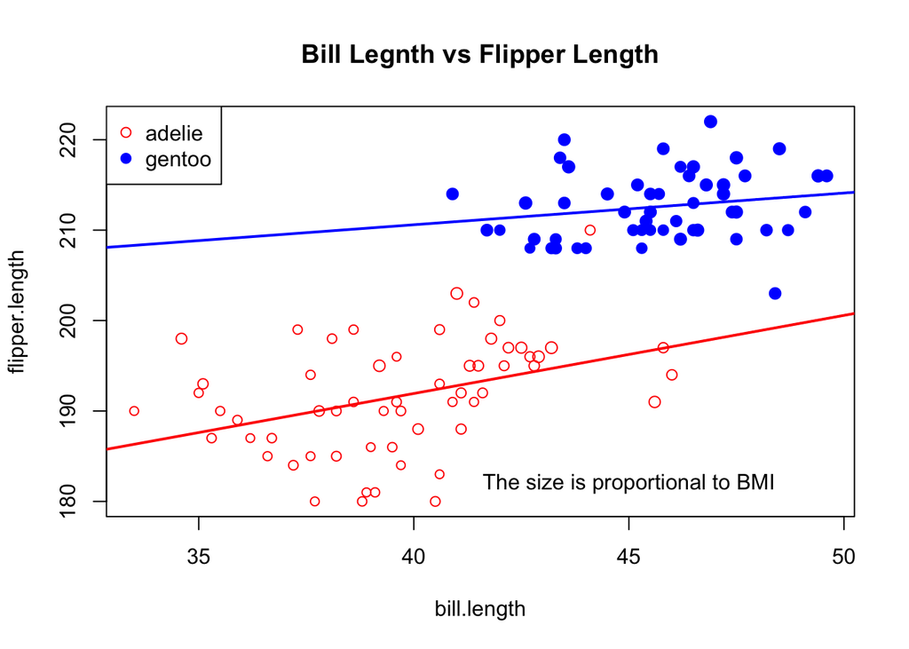